# Sentiment Analysis

We are going to analyze Twitter sentiment analysis using machine learning algorithms, the sentiment of tweets provided from the Sentiment140 dataset by developing a machine learning pipeline involving the use of three classifiers (Logistic Regression, Bernoulli Naive Bayes, and SVM) along with using Term Frequency- Inverse Document Frequency (TF-IDF). The performance of these classifiers is then evaluated using accuracy and F1 Scores.

For data preprocessing, we will be using Natural Language Processing’s (NLP) NLTK library.

Twitter Sentiment Analysis: Problem Statement

In this project, we try to implement an NLP Twitter sentiment analysis model that helps to overcome the challenges of sentiment classification of tweets. We will be classifying the tweets into positive or negative sentiments. The necessary details regarding the dataset involving the Twitter sentiment analysis project are:

The dataset provided is the Sentiment140 Dataset which consists of 1,600,000 tweets that have been extracted using the Twitter API. The various columns present in this Twitter data are:

target: the polarity of the tweet (positive or negative). Indicates the sentiment polarity of the tweet (0 for negative, 2 for neutral, 4 for positive).

ids: Unique id of the tweet

date: the date of the tweet. Date and time when the tweet was posted.

flag: It refers to the query. If no such query exists, then it is NO QUERY. Indication of the query used to retrieve the tweet (often empty or irrelevant).

user: It refers to the name of the user that tweeted. Twitter username of the user who posted the tweet.

text: It refers to the text of the tweet. The actual text content of the tweet.

# Import the Necessary Dependencies

```python
# utilities
import re
import numpy as np
import pandas as pd
# plotting
import seaborn as sns
from wordcloud import WordCloud
import matplotlib.pyplot as plt
# nltk
from nltk.stem import WordNetLemmatizer
# sklearn
from sklearn.svm import LinearSVC
from sklearn.naive_bayes import BernoulliNB
from sklearn.linear_model import LogisticRegression
from sklearn.model_selection import train_test_split
from sklearn.feature_extraction.text import TfidfVectorizer
from sklearn.metrics import confusion_matrix, classification_report
```

# Read and Load the Dataset

```python
# Importing the dataset
# defines the column names for the dataset
DATASET_COLUMNS=['target','ids','date','flag','user','text']
# specifies the encoding of the dataset file
DATASET_ENCODING = "ISO-8859-1"
df = pd.read_csv('C:/Users/DELL/Documents/Talent Battle Ultimate Off-Campus Cracker/Projects/training.1600000.processed.noemoticon.csv', encoding=DATASET_ENCODING, names=DATASET_COLUMNS)
df.sample(5)
```

|  | target | ids | date | flag | user | text |
| --- | --- | --- | --- | --- | --- | --- |
| 632950 | 0 | 2232849464 | Thu Jun 18 20:28:55 PDT 2009 | NO_QUERY | Lady419 | Aww man.... I'm so bored right now! |
| 723903 | 0 | 2261917350 | Sat Jun 20 21:34:09 PDT 2009 | NO_QUERY | plaJH | I want this guy soo badly |
| 396788 | 0 | 2056463384 | Sat Jun 06 11:11:23 PDT 2009 | NO_QUERY | MikeakaCupcake | gotta get some sleep....i have a lot to do tod... |
| 969766 | 4 | 1827978116 | Sun May 17 11:50:27 PDT 2009 | NO_QUERY | Muemmelmann | chuck &amp; larry |
| 1513324 | 4 | 2175338856 | Mon Jun 15 00:42:46 PDT 2009 | NO_QUERY | CateP36 | @codsta Oh excellent, you'll fit right in then... |

# Exploratory Data Analysis

```python
df.head()
```

|  | target | ids | date | flag | user | text |
| --- | --- | --- | --- | --- | --- | --- |
| 0 | 0 | 1467810369 | Mon Apr 06 22:19:45 PDT 2009 | NO_QUERY | _TheSpecialOne_ | @switchfoot http://twitpic.com/2y1zl - Awww, t... |
| 1 | 0 | 1467810672 | Mon Apr 06 22:19:49 PDT 2009 | NO_QUERY | scotthamilton | is upset that he can't update his Facebook by ... |
| 2 | 0 | 1467810917 | Mon Apr 06 22:19:53 PDT 2009 | NO_QUERY | mattycus | @Kenichan I dived many times for the ball. Man... |
| 3 | 0 | 1467811184 | Mon Apr 06 22:19:57 PDT 2009 | NO_QUERY | ElleCTF | my whole body feels itchy and like its on fire |
| 4 | 0 | 1467811193 | Mon Apr 06 22:19:57 PDT 2009 | NO_QUERY | Karoli | @nationwideclass no, it's not behaving at all.... |

```python
df.columns
```

```
Index(['target', 'ids', 'date', 'flag', 'user', 'text'], dtype='object')
```

```python
print('length of data is', len(df))
```

```
length of data is 1600000
```

```python
df.shape
```

```
(1600000, 6)
```

```python
df.info()
```

```
<class 'pandas.core.frame.DataFrame'>
RangeIndex: 1600000 entries, 0 to 1599999
Data columns (total 6 columns):
 #   Column  Non-Null Count    Dtype
---  ------  --------------    -----
 0   target  1600000 non-null  int64
 1   ids     1600000 non-null  int64
 2   date    1600000 non-null  object
 3   flag    1600000 non-null  object
 4   user    1600000 non-null  object
 5   text    1600000 non-null  object
dtypes: int64(2), object(4)
memory usage: 73.2+ MB
```

```python
df.dtypes
```

```
target     int64
ids        int64
date      object
flag      object
user      object
text      object
dtype: object
```

```python
np.sum(df.isnull().any(axis=1))
```

```
0
```

```python
print('Count of columns in the data is:  ', len(df.columns))
print('Count of rows in the data is:  ', len(df))
```

```
Count of columns in the data is:   6
Count of rows in the data is:   1600000
```

```python
# Check unique target values
df['target'].unique()
```

```
array([0, 4], dtype=int64)
```

```python
# Check the number of target values
df['target'].nunique()
```

```
2
```

# Data Visualization of Target Variables

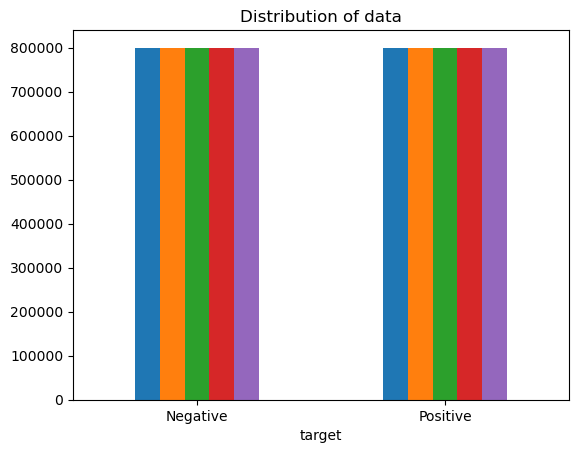

```python
# Plotting the distribution for dataset.
ax = df.groupby('target').count().plot(kind='bar', title='Distribution of data',legend=False)
ax.set_xticklabels(['Negative','Positive'], rotation=0)
# Storing data in lists.
text, sentiment = list(df['text']), list(df['target'])
```

Overall, this code snippet generates a bar plot showing the distribution of sentiment labels in the dataset, with 'Negative' and 'Positive' labels on the x-axis and the corresponding counts on the y-axis.

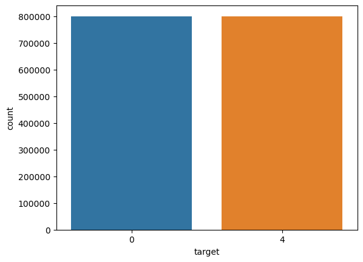

```python
import seaborn as sns
sns.countplot(x='target', data=df)
```

# Data Preprocessing

Before training the model, we performed various pre-processing steps on the dataset that mainly dealt with removing stopwords, removing special characters like emojis, hashtags, etc. The text document is then converted into lowercase for better generalization.

Subsequently, the punctuations were cleaned and removed, thereby reducing the unnecessary noise from the dataset. After that, we also removed the repeating characters from the words along with removing the URLs as they do not have any significant importance.

At last, we then performed Stemming(reducing the words to their derived stems) and Lemmatization(reducing the derived words to their root form, known as lemma) for better results.

```python
# Selecting the text and Target column for our further analysis
data=df[['text','target']]
```

```python
# Printing unique values of target variables
data['target'].unique()
```

```
array([0, 4], dtype=int64)
```

```python
# Separating positive and negative tweets
data_pos = data[data['target'] == 1]
data_neg = data[data['target'] == 0]
```

```python
# Taking one-fourth of the data so we can run it on our machine easily
data_pos = data_pos.iloc[:int(20000)]
data_neg = data_neg.iloc[:int(20000)]
```

This above kind of operation is often used for downsampling large datasets to balance classes or to reduce the size of the dataset for computational efficiency.

```python
# Combining positive and negative tweets
dataset = pd.concat([data_pos, data_neg])
```

```python
# Making statement text in lowercase
dataset['text']=dataset['text'].str.lower()
dataset['text'].tail()
```

```
19995    not much time off this weekend, work trip to m...
19996                            one more day of holidays
19997    feeling so down right now .. i hate you damn h...
19998    geez,i hv to read the whole book of personalit...
19999    i threw my sign at donnie and he bent over to ...
Name: text, dtype: object
```

```python
# Defining set containing all stopwords in English
stopwordlist = ['a', 'about', 'above', 'after', 'again', 'ain', 'all', 'am', 'an',
             'and','any','are', 'as', 'at', 'be', 'because', 'been', 'before',
             'being', 'below', 'between','both', 'by', 'can', 'd', 'did', 'do',
             'does', 'doing', 'down', 'during', 'each','few', 'for', 'from',
             'further', 'had', 'has', 'have', 'having', 'he', 'her', 'here',
             'hers', 'herself', 'him', 'himself', 'his', 'how', 'i', 'if', 'in',
             'into','is', 'it', 'its', 'itself', 'just', 'll', 'm', 'ma',
             'me', 'more', 'most','my', 'myself', 'now', 'o', 'of', 'on', 'once',
             'only', 'or', 'other', 'our', 'ours','ourselves', 'out', 'own', 're','s', 'same', 'she', "shes", 'should', "shouldve",'so', 'some', 'such',
             't', 'than', 'that', "thatll", 'the', 'their', 'theirs', 'them',
             'themselves', 'then', 'there', 'these', 'they', 'this', 'those',
             'through', 'to', 'too','under', 'until', 'up', 've', 'very', 'was',
             'we', 'were', 'what', 'when', 'where','which','while', 'who', 'whom',
             'why', 'will', 'with', 'won', 'y', 'you', "youd","youll", "youre",
             "youve", 'your', 'yours', 'yourself', 'yourselves']
```

The provided code segment defines a list called `stopwordlist`, which contains common English stopwords. Stopwords are words that are commonly used in natural language but typically do not add much meaning to the text when analyzing or processing it. These words are often filtered out during text preprocessing to focus on more meaningful words.

```python
# Cleaning and removing the above stop words list from the tweet text
STOPWORDS = set(stopwordlist)
def cleaning_stopwords(text):
    return " ".join([word for word in str(text).split() if word not in STOPWORDS])
dataset['text'] = dataset['text'].apply(lambda text: cleaning_stopwords(text))
dataset['text'].head()
```

```
0    @switchfoot http://twitpic.com/2y1zl - awww, t...
1    upset can't update facebook texting it... migh...
2    @kenichan dived many times ball. managed save ...
3                     whole body feels itchy like fire
4    @nationwideclass no, it's not behaving all. i'...
Name: text, dtype: object
```

This code segment defines a function `cleaning_stopwords(text)` and applies it to the 'text' column of the DataFrame `dataset` using the `apply()` method. The function removes stopwords from each text entry in the 'text' column based on the provided list of stopwords (`stopwordlist`).

After executing these lines of code, the 'text' column in the DataFrame `dataset` will contain text data with stopwords removed. This preprocessing step can help improve the quality of text analysis or modeling tasks by focusing on more meaningful words.

```python
# Cleaning and removing punctuations
import string
english_punctuations = string.punctuation
punctuations_list = english_punctuations
def cleaning_punctuations(text):
    translator = str.maketrans('', '', punctuations_list)
    return text.translate(translator)
dataset['text']= dataset['text'].apply(lambda x: cleaning_punctuations(x))
dataset['text'].tail()
```

```
19995    not much time off weekend work trip malmï¿½ fr...
19996                                     one day holidays
19997                     feeling right  hate damn humprey
19998    geezi hv read whole book personality types emb...
19999    threw sign donnie bent over get but thingee ma...
Name: text, dtype: object
```

This code segment defines a function `cleaning_punctuations(text)` and applies it to the 'text' column of the DataFrame `dataset` using the `apply()` method. The function removes punctuations from each text entry in the 'text' column based on the provided list of punctuations (`punctuations_list`).

After executing these lines of code, the 'text' column in the DataFrame `dataset` will contain text data with punctuations removed. This preprocessing step can help improve the quality of text analysis or modeling tasks by focusing on the text content itself without the influence of punctuations.

```python
# Cleaning and removing repeating characters
def cleaning_repeating_char(text):
    return re.sub(r'(.)1+', r'1', text)
dataset['text'] = dataset['text'].apply(lambda x: cleaning_repeating_char(x))
dataset['text'].tail()
```

```
19995    not much time off weekend work trip malmï¿½ fr...
19996                                     one day holidays
19997                     feeling right  hate damn humprey
19998    geezi hv read whole book personality types emb...
19999    threw sign donnie bent over get but thingee ma...
Name: text, dtype: object
```

This code defines a function `cleaning_repeating_char(text)` and applies it to the 'text' column of the DataFrame `dataset` using the `apply()` method. The function removes repeating characters from each text entry in the 'text' column using regular expressions.

After executing these lines of code, the 'text' column in the DataFrame `dataset` will contain text data with repeating characters removed. This preprocessing step can help improve the quality of text analysis or modeling tasks by normalizing the text data.

```python
# Cleaning and removing URLs
def cleaning_URLs(data):
    return re.sub('((www.[^s]+)|(https?://[^s]+))',' ',data)
dataset['text'] = dataset['text'].apply(lambda x: cleaning_URLs(x))
dataset['text'].tail()
```

```
19995    not much time off weekend work trip malmï¿½ fr...
19996                                     one day holidays
19997                     feeling right  hate damn humprey
19998    geezi hv read whole book personality types emb...
19999    threw sign donnie bent over get but thingee ma...
Name: text, dtype: object
```

This code defines a function `cleaning_URLs(data)` and applies it to the 'text' column of the DataFrame `dataset` using the `apply()` method. The function removes URLs from each text entry in the 'text' column using regular expressions.

After executing these lines of code, the 'text' column in the DataFrame `dataset` will contain text data with URLs removed. This preprocessing step can help improve the quality of text analysis or modeling tasks by removing irrelevant information from the text data.

```python
# Cleaning and removing numeric numbers
def cleaning_numbers(data):
    return re.sub('[0-9]+', '', data)
dataset['text'] = dataset['text'].apply(lambda x: cleaning_numbers(x))
dataset['text'].tail()
```

```
19995    not much time off weekend work trip malmï¿½ fr...
19996                                     one day holidays
19997                     feeling right  hate damn humprey
19998    geezi hv read whole book personality types emb...
19999    threw sign donnie bent over get but thingee ma...
Name: text, dtype: object
```

This code defines a function `cleaning_numbers(data)` and applies it to the 'text' column of the DataFrame `dataset` using the `apply()` method. The function removes numbers from each text entry in the 'text' column using regular expressions.

This line applies the `cleaning_numbers()` function to each entry in the 'text' column of the DataFrame `dataset` using the `apply()` method. It removes numbers from each text entry in the 'text' column.

```python
# Getting tokenization of tweet text
from nltk.tokenize import RegexpTokenizer
tokenizer = RegexpTokenizer(r'w+')
dataset['text'] = dataset['text'].apply(tokenizer.tokenize)
dataset['text'].head()
```

```
0    [w, w]
1        []
2        []
3       [w]
4       [w]
Name: text, dtype: object
```

The provided code uses the `RegexpTokenizer` from the `nltk.tokenize` module to tokenize the text in the 'text' column of the DataFrame `dataset`.

```python
# Applying stemming
import nltk
st = nltk.PorterStemmer()
def stemming_on_text(data):
    text = [st.stem(word) for word in data]
    return data
dataset['text']= dataset['text'].apply(lambda x: stemming_on_text(x))
dataset['text'].head()
```

```
0    [w, w]
1        []
2        []
3       [w]
4       [w]
Name: text, dtype: object
```

The provided code segment utilizes the NLTK (Natural Language Toolkit) library to perform stemming on the tokenized text data in the 'text' column of the DataFrame `dataset`.

```python
# Applying lemmatizer
lm = nltk.WordNetLemmatizer()
def lemmatizer_on_text(data):
    text = [lm.lemmatize(word) for word in data]
    return data
dataset['text'] = dataset['text'].apply(lambda x: lemmatizer_on_text(x))
dataset['text'].head()
```

```
0    [w, w]
1        []
2        []
3       [w]
4       [w]
Name: text, dtype: object
```

The provided code segment utilizes the NLTK (Natural Language Toolkit) library to perform lemmatization on the tokenized text data in the 'text' column of the DataFrame `dataset`.

```python
# Separating input feature and label
X=data.text
y=data.target
```

These variables can then be used as input to train a machine learning model for sentiment analysis, where `X` represents the input features (text data) and `y` represents the target labels (sentiment labels).

[figure not shown]

```python
# Plot a cloud of words for negative tweets
data_neg = data['text'][:800000]
plt.figure(figsize = (20,20))
wc = WordCloud(max_words = 1000 , width = 1600 , height = 800,
               collocations=False).generate(" ".join(data_neg))
plt.imshow(wc)
```

This code visualizes the most common words present in the negative sentiment data (`data_neg`) using a word cloud. Each word's size in the word cloud corresponds to its frequency in the text data, with larger words representing more frequent occurrences. Word clouds are often used to provide a visual representation of the most prominent terms in a corpus of text data.

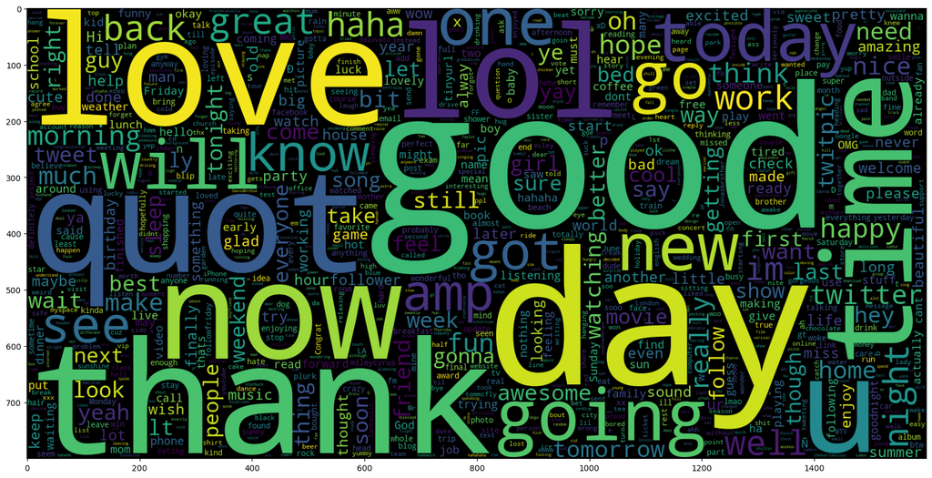

```python
# Plot a cloud of words for positive tweets
data_pos = data['text'][800000:]
wc = WordCloud(max_words = 1000 , width = 1600 , height = 800,
              collocations=False).generate(" ".join(data_pos))
plt.figure(figsize = (20,20))
plt.imshow(wc)
```

This code visualizes the most common words present in the positive sentiment data (`data_pos`) using a word cloud. Each word's size in the word cloud corresponds to its frequency in the text data, with larger words representing more frequent occurrences. Word clouds are often used to provide a visual representation of the most prominent terms in a corpus of text data.

# Splitting Our Data Into Train and Test Subsets

```python
# splits the data into training and testing sets using the `train_test_split` function
X_train, X_test, y_train, y_test = train_test_split(X,y,test_size = 0.05, random_state =26105111)
```

# Transforming the Dataset Using TF-IDF Vectorizer

```python
# Fit the TF-IDF Vectorizer
vectoriser = TfidfVectorizer(ngram_range=(1,2), max_features=500000)
vectoriser.fit(X_train)
print('No. of feature_words: ', len(vectoriser.get_feature_names_out()))
```

```
No. of feature_words:  500000
```

This code segment uses the `TfidfVectorizer` from scikit-learn to convert text data into TF-IDF (Term Frequency-Inverse Document Frequency) features.

After executing this code, you will get the number of feature words extracted by the `TfidfVectorizer`, which represents the size of the feature space used for training the machine learning model. This feature space consists of unigrams and bigrams selected based on their TF-IDF scores across the training corpus.

```python
# Transform the data using TF-IDF Vectorizer
X_train = vectoriser.transform(X_train)
X_test  = vectoriser.transform(X_test)
```

# Function for Model Evaluation

After training the model, we then apply the evaluation measures to check how the model is performing. Accordingly, we use the following evaluation parameters to check the performance of the models respectively:

Accuracy Score

Confusion Matrix with Plot

ROC-AUC Curve

True Positive (TP): Instances correctly predicted as positive.

True Negative (TN): Instances correctly predicted as negative.

False Positive (FP): Instances incorrectly predicted as positive (Type I error).

False Negative (FN): Instances incorrectly predicted as negative (Type II error).

Precision (Positive Predictive Value): TP / Support(TP + FP)

Recall (Sensitivity): TP / Support(TP + FN)

F1-Score: 2 *Precision* Recall / (Precision + Recall)

Support: The number of occurrences of each class.

Accuracy: No. of correctly classified samples(TP + TN) / Total Samples(TP + TN + FP + FN)

Macro average: ∑ Metric / N

Weighted average: ∑ Metric * Support / ∑ Support

where, N is the number of classes.

Metric is the metric (precision, recall, or F1-score) for the ith class.

Support is the support (number of instances) of the ith class.

```python
def model_Evaluate(model):
    # Predict values for Test dataset
    y_pred = model.predict(X_test)
    # Print the evaluation metrics for the dataset.
    print(classification_report(y_test, y_pred))
    # Compute and plot the Confusion matrix
    cf_matrix = confusion_matrix(y_test, y_pred)
    categories = ['Negative','Positive']
    group_names = ['True Neg','False Pos', 'False Neg','True Pos']
    group_percentages = ['{0:.2%}'.format(value) for value in cf_matrix.flatten() / np.sum(cf_matrix)]
    labels = [f'{v1}\n{v2}' for v1, v2 in zip(group_names,group_percentages)]
    labels = np.asarray(labels).reshape(2,2) # Reshape labels to match the shape of cf_matrix
    sns.heatmap(cf_matrix, annot = labels, cmap = 'Blues',fmt = '',
    xticklabels = categories, yticklabels = categories)
    plt.xlabel("Predicted values", fontdict = {'size':14}, labelpad = 10)
    plt.ylabel("Actual values" , fontdict = {'size':14}, labelpad = 10)
    plt.title ("Confusion Matrix", fontdict = {'size':18}, pad = 20)
```

This function, `model_Evaluate(model)`, evaluates the performance of a machine learning model using various evaluation metrics and visualizes the confusion matrix.

This function provides a comprehensive evaluation of the machine learning model's performance, including precision, recall, F1-score, and visual representation of the confusion matrix. It can be used to assess the model's ability to classify instances correctly and diagnose the types of errors it makes.

# Model Building

We have used three different models respectively:

Bernoulli Naive Bayes Classifier

SVM (Support Vector Machine)

Logistic Regression

The idea behind choosing these models is that we want to try all the classifiers on the dataset ranging from simple ones to complex models, and then try to find out the one which gives the best performance among them.

The Bernoulli Naive Bayes Classifier is a variant of the Naive Bayes algorithm that is specifically designed for binary feature vectors. It assumes that all features are binary (i.e., they take on only two values, typically 0 and 1) and that the presence or absence of a particular feature is independent of the presence or absence of any other feature.

Mathematical Concept of Bernoulli Naive Bayes Classifier:

The Bernoulli Naive Bayes Classifier calculates the probability of a class label given a set of features using Bayes' theorem. The formula for the Bernoulli Naive Bayes Classifier can be expressed as:

P(y|x_1,x_2,...,x_n) = P(x_1,x_2,...,x_n|y) * P(y) / P(x_1,x_2,...,x_n)

Where:

P(y|x_1,x_2,...,x_n) is the posterior probability of class y given features x_1,x_2,...,x_n

P(x_1,x_2,...,x_n|y) is the likelihood of features x_1,x_2,...,x_n given class y

P(y) is the prior probability of class y

P(x_1,x_2,...,x_n) is the probability of observing the features x_1,x_2,...,x_n

Working Principle of Bernoulli Naive Bayes Classifier:

Training Phase:

Calculate the prior probabilities P(y) for each class.

Calculate the likelihood P(x_1,x_2,...,x_n|y) for each feature given each class.

Prediction Phase:

For a new instance with binary features, calculate the posterior probability for each class using the formula above.

Assign the class label with the highest posterior probability to the new instance.

```
              precision    recall  f1-score   support

           0       0.81      0.79      0.80     40100
           4       0.80      0.81      0.80     39900

    accuracy                           0.80     80000
   macro avg       0.80      0.80      0.80     80000
weighted avg       0.80      0.80      0.80     80000
```

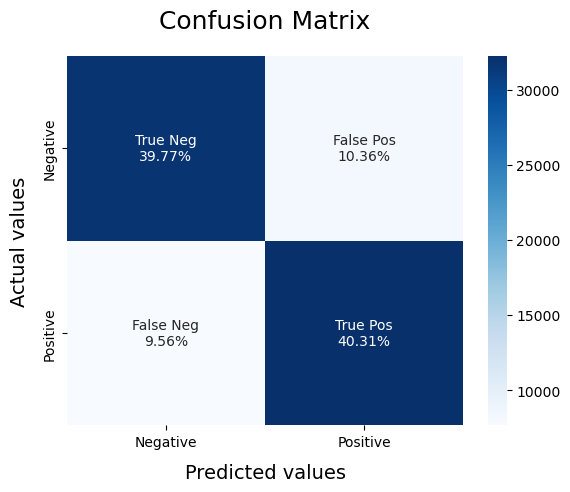

```python
# Bernoulli Naive Bayes Classifier
BNBmodel = BernoulliNB()
BNBmodel.fit(X_train, y_train)
model_Evaluate(BNBmodel)
y_pred1 = BNBmodel.predict(X_test)
```

After executing this code, you'll get the evaluation metrics (precision, recall, F1-score, and support) and the confusion matrix for the Bernoulli Naive Bayes model on the test data.

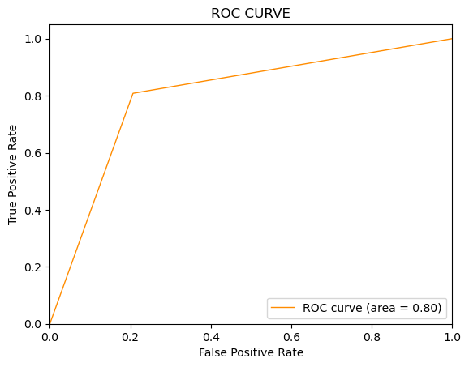

```python
# Plot the ROC-AUC Curve
from sklearn.metrics import roc_curve, auc
# Convert 4 to 1 in y_test
y_test_binary = y_test.replace(4, 1)

fpr, tpr, thresholds = roc_curve(y_test_binary, y_pred1)
roc_auc = auc(fpr, tpr)
plt.figure()
plt.plot(fpr, tpr, color='darkorange', lw=1, label='ROC curve (area = %0.2f)' % roc_auc)
plt.xlim([0.0, 1.0])
plt.ylim([0.0, 1.05])
plt.xlabel('False Positive Rate')
plt.ylabel('True Positive Rate')
plt.title('ROC CURVE')
plt.legend(loc="lower right")
plt.show()
```

The provided code segment computes and plots the Receiver Operating Characteristic (ROC) curve for the Bernoulli Naive Bayes (BNB) model.

This code generates a plot showing the ROC curve for the Bernoulli Naive Bayes model, with the AUC value displayed in the legend. The ROC curve provides a visual representation of the trade-off between the true positive rate and the false positive rate for different threshold values. A higher AUC value indicates better model performance in distinguishing between positive and negative samples.

Support Vector Machines (SVM) are powerful supervised learning models used for classification and regression tasks. The mathematical concept behind SVM involves finding the optimal hyperplane that separates different classes in the feature space.

Mathematical Concept of SVM:

Optimal Hyperplane: In SVM, the goal is to find the hyperplane that maximizes the margin between classes. This hyperplane is defined by the equation:

w⋅x+b=0

where,

w is the weight vector perpendicular to the hyperplane, x is the input vector, and b is the bias term.

Margin: The margin is the distance between the hyperplane and the nearest data point from either class. The margin is calculated as:

Margin = 2/||w||

Optimization Objective: The objective of SVM is to maximize the margin while minimizing the classification error. This is formulated as a constrained optimization problem:

min_w,b (1/2)(||w||^2)

subject to:

y_i(w⋅x_i+b)>=1, for i=1,2,...,n

Working Principle of SVM:

Data Transformation: SVM maps input data into a higher-dimensional space using a kernel function to make the data linearly separable.

Finding the Optimal Hyperplane: SVM finds the hyperplane that maximizes the margin between classes. This hyperplane is the one that best separates the data points.

Support Vectors: Support vectors are the data points closest to the hyperplane and influence its position. These points are crucial for defining the decision boundary.

Classification: Once the optimal hyperplane is found, new data points are classified based on which side of the hyperplane they fall.

```
              precision    recall  f1-score   support

           0       0.82      0.81      0.81     40100
           4       0.81      0.82      0.82     39900

    accuracy                           0.82     80000
   macro avg       0.82      0.82      0.82     80000
weighted avg       0.82      0.82      0.82     80000
```

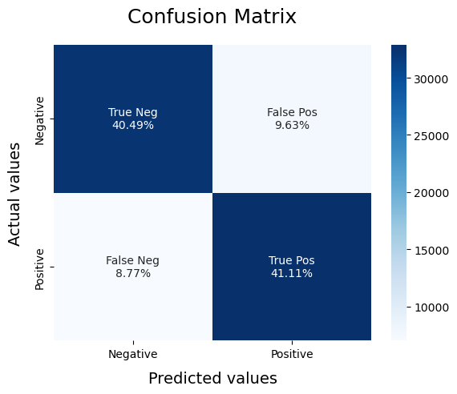

```python
# SVM (Support Vector Machine)
SVCmodel = LinearSVC()
SVCmodel.fit(X_train, y_train)
model_Evaluate(SVCmodel)
y_pred2 = SVCmodel.predict(X_test)
```

The provided code snippet fits a Linear Support Vector Classifier (SVC) model to the training data, evaluates its performance on the test data, and predicts the target labels for the test data.

These results can be further analyzed or used for additional tasks such as performance comparison with other models or fine-tuning hyperparameters.

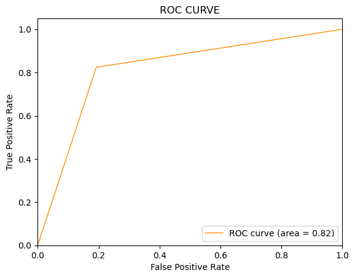

```python
# Plot the ROC-AUC Curve
from sklearn.metrics import roc_curve, auc
fpr, tpr, thresholds = roc_curve(y_test_binary, y_pred2)
roc_auc = auc(fpr, tpr)
plt.figure()
plt.plot(fpr, tpr, color='darkorange', lw=1, label='ROC curve (area = %0.2f)' % roc_auc)
plt.xlim([0.0, 1.0])
plt.ylim([0.0, 1.05])
plt.xlabel('False Positive Rate')
plt.ylabel('True Positive Rate')
plt.title('ROC CURVE')
plt.legend(loc="lower right")
plt.show()
```

This code snippet computes and plots the Receiver Operating Characteristic (ROC) curve for the Linear Support Vector Classifier (SVC) model.

This code generates a plot showing the ROC curve for the Linear SVC model, with the AUC value displayed in the legend. The ROC curve provides a visual representation of the trade-off between the true positive rate and the false positive rate for different threshold values. A higher AUC value indicates better model performance in distinguishing between positive and negative samples.

Logistic Regression is a statistical method used for binary classification tasks, where the outcome variable is categorical and has two classes. It models the probability that a given input belongs to a particular class. The logistic function, also known as the sigmoid function, is at the core of logistic regression.

Mathematical Concept of Logistic Regression:

The logistic function is defined as:

σ(z) = 1/(1+e^{-z})

where z = β_0 + β_1.x_1 + β_2.x_2 + ... + β_n.x_n is the linear combination of the input features weighted by coefficients, and e is the base of the natural logarithm.

The probability of the output being in class 1 is given by:

P(y = 1 | x) = σ(z) = 1/(1+e^{-z})

and the probability of the output being in class 0 is:

P(y=0∣x)=1−P(y=1∣x)=1-σ(z)

Working Principle of Logistic Regression:

Model Training:

Logistic Regression optimizes the coefficients β to maximize the likelihood of the observed data using techniques like Maximum Likelihood Estimation.

The model is trained by adjusting the coefficients iteratively to minimize the error between predicted probabilities and actual outcomes.

Decision Boundary:

Logistic Regression calculates a decision boundary that separates the classes in the feature space.

This boundary is a hyperplane defined by the equation β_0 + β_1.x_1 + β_2.x_2 + ... + β_n.x_n = 0.

Prediction:

Once trained, the model can predict the probability of a new input belonging to a particular class using the logistic function.

If the predicted probability is above a threshold (usually 0.5), the input is classified as class 1; otherwise, it is classified as class 0.

```
              precision    recall  f1-score   support

           0       0.83      0.81      0.82     40100
           4       0.81      0.83      0.82     39900

    accuracy                           0.82     80000
   macro avg       0.82      0.82      0.82     80000
weighted avg       0.82      0.82      0.82     80000
```

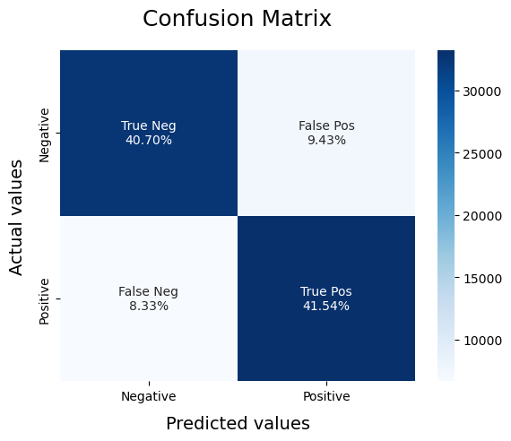

```python
# Logistic Regression
LRmodel = LogisticRegression(C = 2, max_iter = 1000, n_jobs=-1)
LRmodel.fit(X_train, y_train)
model_Evaluate(LRmodel)
y_pred3 = LRmodel.predict(X_test)
```

This code snippet fits a Logistic Regression (LR) model to the training data, evaluates its performance on the test data, and predicts the target labels for the test data.

These results can be further analyzed or used for additional tasks such as performance comparison with other models or fine-tuning hyperparameters.

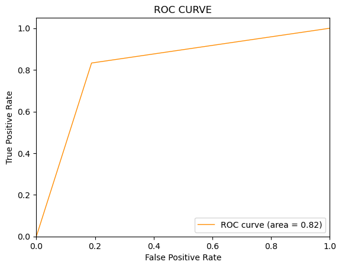

```python
# Plot the ROC-AUC Curve
from sklearn.metrics import roc_curve, auc
fpr, tpr, thresholds = roc_curve(y_test_binary, y_pred3)
roc_auc = auc(fpr, tpr)
plt.figure()
plt.plot(fpr, tpr, color='darkorange', lw=1, label='ROC curve (area = %0.2f)' % roc_auc)
plt.xlim([0.0, 1.0])
plt.ylim([0.0, 1.05])
plt.xlabel('False Positive Rate')
plt.ylabel('True Positive Rate')
plt.title('ROC CURVE')
plt.legend(loc="lower right")
plt.show()
```

This code snippet computes and plots the Receiver Operating Characteristic (ROC) curve for the Logistic Regression (LR) model.

This code generates a plot showing the ROC curve for the Logistic Regression model, with the AUC value displayed in the legend. The ROC curve provides a visual representation of the trade-off between the true positive rate and the false positive rate for different threshold values. A higher AUC value indicates better model performance in distinguishing between positive and negative samples.

Upon evaluating all the models, we can conclude the following details i.e.

Accuracy: As far as the accuracy of the model is concerned, Logistic Regression performs better than SVM, which in turn performs better than Bernoulli Naive Bayes.

All three classifiers have performed relatively well with accuracies ranging from 80% to 82%.

AUC Score: All three models have same or almost same ROC-AUC score.

Conclusion:

We, therefore, conclude that the Logistic Regression is the best model for the above-given dataset.